# Projeto final da disciplina - HO236 – Econometria de séries temporais

Objetivo

Como primeiro contato com a modelagem de séries temporais e visando a implementação na tese planejada com foco em indústria e inovação aeroespacial, foi pensado uma análise da influência da política monetária, câmbio flutuante e investimentos de banco desenvolvimentista na produção industrial de manufaturados. Esse será um primeiro passo para aprofundar na análise da dinâmica macroeconômica e os impactos na indústria aeroespacial nacional. Neste trabalho serão aplicadas análises para indústria de transformação no geral. Foram adicionadas variáveis que possam refletir a demanda agregada do setor, além dos riscos/incertezas nacionais e internacionais no investimento industrial.

Variáveis:

- Selic -> TSA
- Câmbio -> TXC
- Índice de produção da indústria de transformação -> IPIT
- Utilização da capacidade da indústria de transformação -> CUIT
- Desembolso de crédito corrente do BNDES para indústria de transformação -> DCB
- Embi (JPMorgan Emerging Market Bond Index - Brasil) -> EMBI
- Vix (CBOE Volatility Index da Chicago Board Options Exchange) -> VIX
- Exportação de produtos da indústria de transformação -> EXIT
- Importação de produtos da indústria de transformação -> IMIT

Fonte de dados: Os dados utilizados foram obtidos da API do Banco Central , Ipea, Comex e BNDES.

Serão aplicados os testes estatísticos aprendidos ao decorrer da disciplina e implementação na linguagem python do modelo VAR, conforme adequação das variáveis selecionadas. Será abordada uma breve análise com a literatura pós-keynesiana.

## Resumo

- Aqui há um breve resumo da matriz de exportação e importação da indústria de transformação obtidas no site do COMEX.

### Exportação

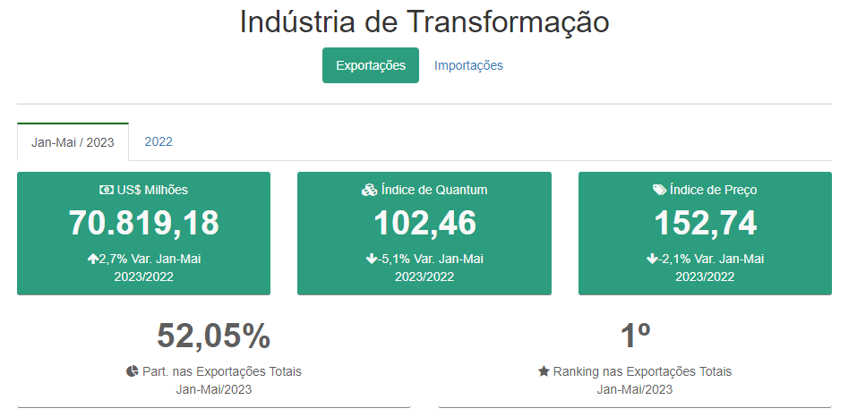

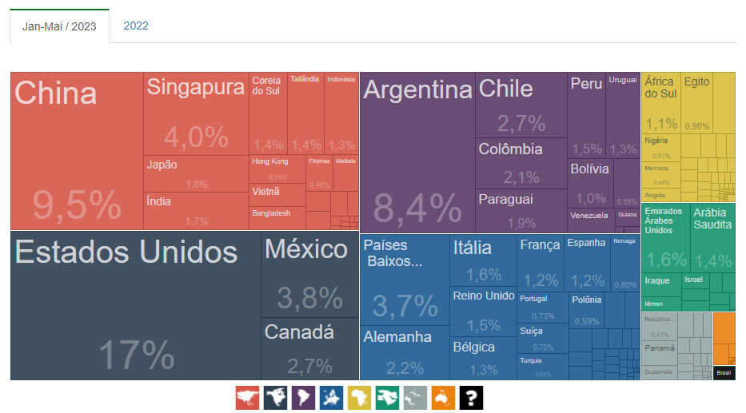

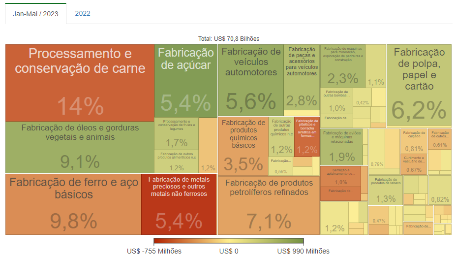

### Importação

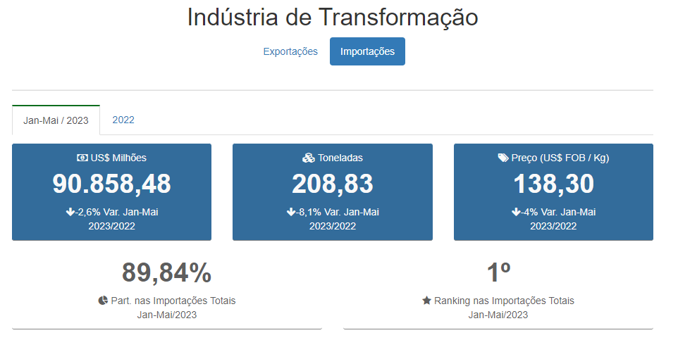

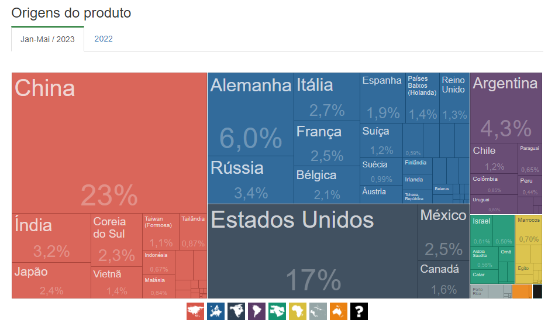

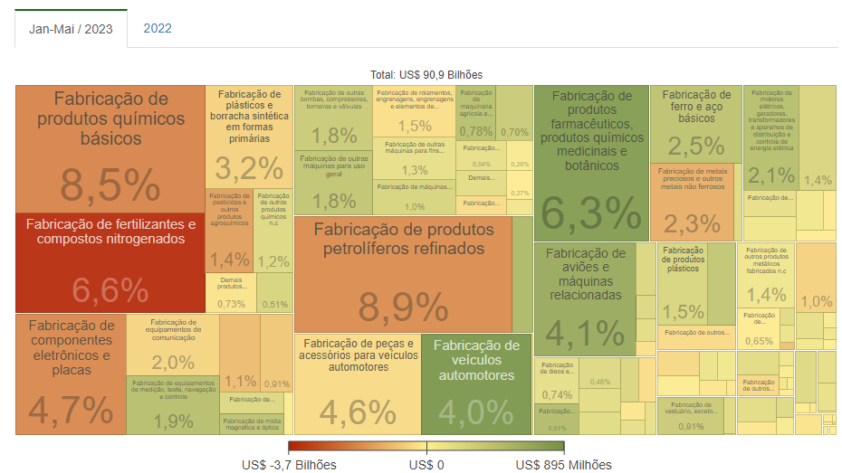

### Análise

- Nota-se que há uma quantidade maior de importação de bens de capitais com alto valor agregado necessários para produção das firmas nacionais. Já as exportações são caracterizadas por produtos com menor valor agregado em relação as importações, o que reforça a necessidade de investimentos em projetos de Pesquisa & Desenvolvimento a longo prazo.

## Modelagem

### Importação das Bibliotecas

```python
#Import the required modules for data generation
import numpy as np
#Import the required modules for plot creation:
import matplotlib.pyplot as plt
#Import the required modules for DataFrame creation:
import pandas as pd

#Import the required modules for TimeSeries data generation:
import statsmodels.api as sm
#Import the required modules for test statistic calculation:
import statsmodels.stats as sm_stat
#Import the required modules for model estimation:
import statsmodels.tsa as smt
#Import the required modules for optimization:
import scipy as scipy
#We also need additional data:
import statsmodels.formula.api as smf
from statsmodels.tsa.stattools import adfuller
from statsmodels.tsa.stattools import kpss as kpss_t

from random import randrange
from pandas import Series
from matplotlib import pyplot
from statsmodels.tsa.seasonal import seasonal_decompose

from bcb import currency
from bcb import sgs

import yfinance as yf
import fix_yahoo_finance as yf
import pandas_datareader.data as web

import datetime

import pandas as pd
import numpy as np
import matplotlib.pyplot as plt
%matplotlib inline

# Import Statsmodels
from statsmodels.tsa.api import VAR
from statsmodels.tsa.stattools import adfuller
from statsmodels.tools.eval_measures import rmse, aic
```

### Setup

```python
#####################
# pandas dataframes #
#####################

# set cientific notation for pandas
pd.set_option(
    "display.float_format", "{:,.3f}".format
)  # used in some places like SeriesFormatter
#pd.set_option(
#    "display.precision", 3
#)  # for regular formatting as well as scientific notation
#pd.set_option(
#    "styler.format.precision", 3
#)  # The precision for floats and complex numbers
# don't truncate columns
pd.set_option("display.max_colwidth", 100)  # None for unlimited
# display all columns
pd.set_option("display.max_columns", None)
# display up to 100 rows
pd.set_option("display.max_rows", 100)
# display dimensions
pd.set_option("display.show_dimensions", True)
# define decimals and thousand separation
#pd.set_option("styler.format.decimal", ",")
#pd.set_option("styler.format.thousands", ".")

####################
# matplotlib plots #
####################

# set default plt figure size
plt.rcParams["figure.figsize"] = [10, 5]
# figure suptitle
plt.rcParams["figure.titlesize"] = "large"
plt.rcParams["figure.titleweight"] = "bold"
# set default plt font size
plt.rcParams["font.size"] = 12
# font weight
# plt.rcParams["font.weight"] = "bold"
# title location
plt.rcParams["axes.titlelocation"] = "left"
# title size
plt.rcParams["axes.titlesize"] = "large"
# title wight
plt.rcParams["axes.titleweight"] = "bold"
# plt.rcParams["axes.labelweight"] = "bold"
# spines
plt.rcParams["axes.spines.top"] = False
plt.rcParams["axes.spines.right"] = False
# axis labels
plt.rcParams["xaxis.labellocation"] = "left"
plt.rcParams["yaxis.labellocation"] = "top"
# figure layout
plt.rcParams["figure.autolayout"] = False
# save figures
plt.rcParams["savefig.dpi"] = 900
plt.rcParams["savefig.facecolor"] = "white"
plt.rcParams["savefig.bbox"] = "tight"
plt.rcParams["savefig.format"] = "png"

# set fivethirtyeight pallete
plt.style.use("fivethirtyeight")

#####################
# jupyter notebooks #
#####################

# set cell size to be expanded
#display(HTML("<style>.container { width:100% !important; }</style>"))
```

### Dataprep

```python
#ETL dos dados obs.:
df = sgs.get({'indice_ind_transf':28505},
             start ='1995-01-31', end='2023-06-30')
df.dropna(inplace=True)
df = df.resample('1M').mean()
curr = currency.get(['USD'], start = '1995-01-31', end = '2023-06-30')
selic = pd.read_excel('../dados/selic_acum_ipea.xlsx')
bndes = pd.read_excel('../dados/desembolso_corrente_bndes_industria.xlsx')
cap = pd.read_excel('../dados/capacidade_instalada_ind.xlsx')
embi = pd.read_excel('../dados/embi_risco.xlsx')
imp = pd.read_excel('../dados/importacao_ind_transf.xlsx')
exp = pd.read_excel('../dados/exportacao_ind_transf.xlsx')
vix = pd.read_excel('../dados/indice_vix.xlsx')
selic.set_index('data', inplace=True)
bndes.set_index('data', inplace=True)
cap.set_index('data', inplace=True)
embi.set_index('data', inplace=True)
imp.set_index('data', inplace=True)
exp.set_index('data', inplace=True)
vix.set_index('Date', inplace=True)
selic = selic.resample('1M').mean()
bndes = bndes.resample('1M').mean()
cap = cap.resample('1M').mean()
curr = curr.resample('1M').mean()
embi = embi.resample('1M').mean()
df['cambio'] = curr['USD']
df['bndes_industria'] = bndes['bndes_industria']
df['selic_acum'] = selic['selic_acum']
df['capacidade_uti'] = cap['capacity_utilization_manufacturing_industry_seasonally_adjusted_%_fgv']
df['embi_risco'] = embi['embi_risco']
df['exportacao'] = exp['exportacao_ind_transf_fob']
df['importacao'] = imp['importacao_ind_transf_fob']
df['vix'] = vix['vix']
df.dropna(inplace=True)
df.rename(columns={'vix':'VIX','embi_risco':'EMBI','cambio':'TXC','selic_acum':'TSA','bndes_industria':'DCB',
                   'capacidade_uti':'CUIT','indice_ind_transf':'IPIT','exportacao':'EXIT','importacao':'IMIT'}, inplace=True)
df = df[['EXIT','IPIT','CUIT','DCB','IMIT','TXC','TSA','EMBI','VIX']]
df.head(2)
```

| Date | EXIT | IPIT | CUIT | DCB | IMIT | TXC | TSA | EMBI | VIX |
| --- | --- | --- | --- | --- | --- | --- | --- | --- | --- |
| 2002-01-31 | 3399644841 | 91.8 | 79.8 | 705.136899 | 3375304280 | 2.377932 | 1.53 | 845.363636 | 22.252857 |
| 2002-02-28 | 3099422648 | 94.2 | 79.4 | 1078.935219 | 2934193415 | 2.419600 | 1.25 | 842.800000 | 22.875790 |

```python
## salvando dataset
df.to_excel('../dados/dados_tratados.xlsx')
```

### Data Vizualization

Abaixo são plotados todas as séries utilizadas para a análise.

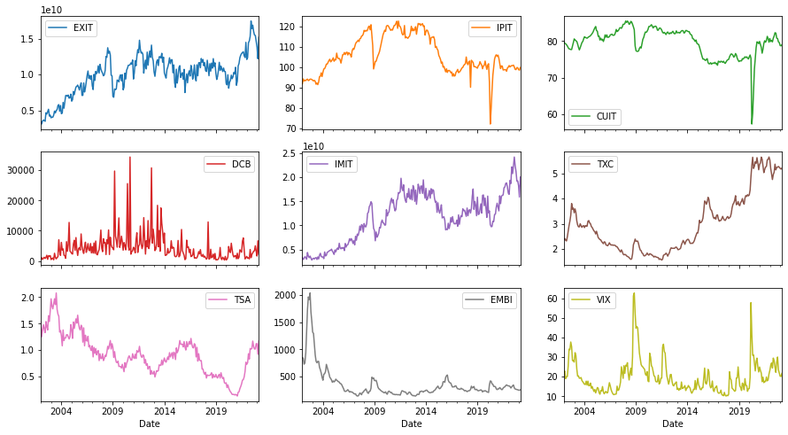

```python
df.plot(subplots=True, layout=(3, 3), figsize=(15,8));
```

### Análise de Estacionariedade da série temporal

#### Função de raízes unitárias ADF e KPSS (biblioteca statsmodels)

```python
def teste_estacionariedade_adf (serie, titulo, rg):
    adf = adfuller(serie, autolag='AIC', regression=rg)
    test_adf = adf[0]
    p_value = adf[1]
    c_value = adf[4]
    c_value = c_value['5%']
    if (test_adf < c_value):
        print('A Série de '+ titulo +' É estacionária para o teste adf com ' + rg)
    else:
        print('A Série de '+ titulo +' NÃO É estacionária para o teste adf com ' + rg)
    print('Teste adf: ' + str(test_adf) + ' | %5: '+ str(c_value) +
          ' | p_value: '+ str(p_value)
          )
    print('---------------------------------------------')

def teste_estacionariedade_kpss (serie, titulo, rg):
    kpss = kpss_t(serie, regression=rg)
    test_kpss = kpss[0]
    p_value = kpss[1]
    c_value = kpss[3]
    c_value = c_value['5%']
    if (test_kpss < c_value):
        print('A Série de '+ titulo +' É estacionária para o teste kpss com ' + rg)
    else:
        print('A Série de '+ titulo +' NÃO É estacionária para o teste kpss com ' + rg)
    print('Teste kpss: ' + str(test_kpss) + ' | %5: '+ str(c_value) +
          ' | p_value: '+ str(p_value)
          )
    print('---------------------------------------------')

def log_df (df, col='column'):
    df[col+'_log'] = np.log(df[col])
    df.dropna(inplace=True)
    return df

def diff_df (df, col='column'):
    df[col+'_diff'] = df[col].diff()
    df.dropna(inplace=True)
    return df

def diff_2_df (df, col='column'):
    df[col+'_2_diff'] = df[col].diff().diff()
    df.dropna(inplace=True)
    return df

def diff_3_df (df, col='column'):
    df[col+'_3_diff'] = df[col].diff().diff().diff()
    df.dropna(inplace=True)
    return df
```

#### Aplicação dos testes

Serão aplicados os testes ADF e KPSS, para cada teste será aplicada constante ('c'), e constante + tendência ('ct')

```python
for column in df.columns:
    print(column)
    teste_estacionariedade_adf(df[column], column,'c')
    teste_estacionariedade_adf(df[column], column,'ct')
    teste_estacionariedade_kpss(df[column], column,'c')
    teste_estacionariedade_kpss(df[column], column,'ct')
    print('---------------------------------------------')
```

```
EXIT
A Série de EXIT NÃO É estacionária para o teste adf com c
Teste adf: -2.0412987048132396 | %5: -2.873761835239286 | p_value: 0.2687636200861696
---------------------------------------------
A Série de EXIT NÃO É estacionária para o teste adf com ct
Teste adf: -2.7553131956449937 | %5: -3.4290999471622556 | p_value: 0.2138408095653127
---------------------------------------------
A Série de EXIT NÃO É estacionária para o teste kpss com c
Teste kpss: 1.3655600162769734 | %5: 0.463 | p_value: 0.01
---------------------------------------------
A Série de EXIT NÃO É estacionária para o teste kpss com ct
Teste kpss: 0.30820489063227274 | %5: 0.146 | p_value: 0.01
---------------------------------------------
---------------------------------------------
IPIT
A Série de IPIT NÃO É estacionária para o teste adf com c
Teste adf: -2.5032455268863467 | %5: -2.8729872043802356 | p_value: 0.11468664879142537
---------------------------------------------
A Série de IPIT NÃO É estacionária para o teste adf com ct
Teste adf: -2.636076855074847 | %5: -3.4279178665415597 | p_value: 0.2635689994027791
---------------------------------------------
A Série de IPIT NÃO É estacionária para o teste kpss com c
Teste kpss: 0.5241892894235651 | %5: 0.463 | p_value: 0.03621862850820605
---------------------------------------------
A Série de IPIT NÃO É estacionária para o teste kpss com ct
Teste kpss: 0.45680011520301916 | %5: 0.146 | p_value: 0.01
---------------------------------------------
---------------------------------------------
CUIT
A Série de CUIT É estacionária para o teste adf com c
Teste adf: -3.083100708727522 | %5: -2.8730786194395455 | p_value: 0.027829353091167002
---------------------------------------------
A Série de CUIT É estacionária para o teste adf com ct
Teste adf: -3.9720286112521666 | %5: -3.4279873291861067 | p_value: 0.009632479893603912
---------------------------------------------
A Série de CUIT NÃO É estacionária para o teste kpss com c
Teste kpss: 0.9339854423711861 | %5: 0.463 | p_value: 0.01
---------------------------------------------
A Série de CUIT NÃO É estacionária para o teste kpss com ct
Teste kpss: 0.2401640437180058 | %5: 0.146 | p_value: 0.01
---------------------------------------------
---------------------------------------------
DCB
A Série de DCB NÃO É estacionária para o teste adf com c
Teste adf: -1.8806208608742845 | %5: -2.8735585105960224 | p_value: 0.3412318613481371
---------------------------------------------
A Série de DCB NÃO É estacionária para o teste adf com ct
Teste adf: -2.27162963799596 | %5: -3.4287896430549103 | p_value: 0.44970131044919753
---------------------------------------------
A Série de DCB NÃO É estacionária para o teste kpss com c
Teste kpss: 0.6430706040849327 | %5: 0.463 | p_value: 0.01872085417409703
---------------------------------------------
A Série de DCB NÃO É estacionária para o teste kpss com ct
Teste kpss: 0.4637121327246849 | %5: 0.146 | p_value: 0.01
---------------------------------------------
---------------------------------------------
IMIT
A Série de IMIT NÃO É estacionária para o teste adf com c
Teste adf: -1.3223732919085447 | %5: -2.873761835239286 | p_value: 0.6188753684717518
---------------------------------------------
```

[output not shown]

```
A Série de IMIT NÃO É estacionária para o teste adf com ct
Teste adf: -1.9075620960311324 | %5: -3.4290999471622556 | p_value: 0.6507414570184242
---------------------------------------------
A Série de IMIT NÃO É estacionária para o teste kpss com c
Teste kpss: 1.5690220142486377 | %5: 0.463 | p_value: 0.01
---------------------------------------------
A Série de IMIT NÃO É estacionária para o teste kpss com ct
Teste kpss: 0.32734790977185574 | %5: 0.146 | p_value: 0.01
---------------------------------------------
---------------------------------------------
TXC
A Série de TXC NÃO É estacionária para o teste adf com c
Teste adf: 0.02796031923263183 | %5: -2.8736593200231484 | p_value: 0.960784202164135
---------------------------------------------
A Série de TXC NÃO É estacionária para o teste adf com ct
Teste adf: -2.08931788388518 | %5: -3.4289434905960645 | p_value: 0.5520731351175303
---------------------------------------------
A Série de TXC NÃO É estacionária para o teste kpss com c
Teste kpss: 1.4740929522241315 | %5: 0.463 | p_value: 0.01
---------------------------------------------
A Série de TXC NÃO É estacionária para o teste kpss com ct
Teste kpss: 0.529262419348118 | %5: 0.146 | p_value: 0.01
---------------------------------------------
---------------------------------------------
TSA
A Série de TSA É estacionária para o teste adf com c
Teste adf: -2.9690008453805863 | %5: -2.8735585105960224 | p_value: 0.03789250110757797
---------------------------------------------
A Série de TSA NÃO É estacionária para o teste adf com ct
Teste adf: -2.545853329098582 | %5: -3.4287896430549103 | p_value: 0.3054289291440232
---------------------------------------------
A Série de TSA NÃO É estacionária para o teste kpss com c
Teste kpss: 1.350877703489089 | %5: 0.463 | p_value: 0.01
---------------------------------------------
A Série de TSA NÃO É estacionária para o teste kpss com ct
Teste kpss: 0.16064566087389318 | %5: 0.146 | p_value: 0.03779528260508901
---------------------------------------------
---------------------------------------------
EMBI
A Série de EMBI É estacionária para o teste adf com c
```

[output cut: 11 more lines]

```
---------------------------------------------
VIX
A Série de VIX É estacionária para o teste adf com c
Teste adf: -4.02386205531127 | %5: -2.8730786194395455 | p_value: 0.0012905896366687986
---------------------------------------------
A Série de VIX É estacionária para o teste adf com ct
Teste adf: -4.019542262430902 | %5: -3.4280573478136107 | p_value: 0.00824738358214407
---------------------------------------------
A Série de VIX É estacionária para o teste kpss com c
Teste kpss: 0.14057774237872384 | %5: 0.463 | p_value: 0.1
---------------------------------------------
A Série de VIX É estacionária para o teste kpss com ct
Teste kpss: 0.12272255353296256 | %5: 0.146 | p_value: 0.09310638234636562
---------------------------------------------
---------------------------------------------
```

Após aplicação dos testes de estacionariedade ADF e KPSS, nota-se que apenas a variável de risco externo vix é estacionária. Assim, tem-se que diferenciar as séries não estacionária e verificar novamente com os testes.

```python
dff = df.copy()
cols=['EXIT','IPIT','CUIT','DCB','IMIT','TXC','TSA','EMBI']
for column in cols:
    diff_df(dff, col=column)
```

- Aplicando o teste de estacionariedade nas séries diferenciadas:

```python
cols = ['EXIT_diff','IPIT_diff','CUIT_diff','DCB_diff','IMIT_diff','TXC_diff','TSA_diff','EMBI_diff']
for column in cols:
    print(column)
    teste_estacionariedade_adf(dff[column], column,'c')
    teste_estacionariedade_adf(dff[column], column,'ct')
    teste_estacionariedade_kpss(dff[column], column,'c')
    teste_estacionariedade_kpss(dff[column], column,'ct')
    print('---------------------------------------------')
```

```
EXIT_diff
A Série de EXIT_diff É estacionária para o teste adf com c
Teste adf: -3.51225425429578 | %5: -2.8741347158661448 | p_value: 0.007677900022080203
---------------------------------------------
A Série de EXIT_diff É estacionária para o teste adf com ct
Teste adf: -3.5060889745992156 | %5: -3.429669078807414 | p_value: 0.03874386839432184
---------------------------------------------
A Série de EXIT_diff É estacionária para o teste kpss com c
Teste kpss: 0.04534562373712974 | %5: 0.463 | p_value: 0.1
---------------------------------------------
A Série de EXIT_diff É estacionária para o teste kpss com ct
Teste kpss: 0.04309580911035194 | %5: 0.146 | p_value: 0.1
---------------------------------------------
---------------------------------------------
IPIT_diff
A Série de IPIT_diff É estacionária para o teste adf com c
Teste adf: -15.49933136679949 | %5: -2.873361841566324 | p_value: 2.4271647063123393e-28
---------------------------------------------
A Série de IPIT_diff É estacionária para o teste adf com ct
Teste adf: -15.507015542505757 | %5: -3.4284895182621864 | p_value: 1.3855323725843325e-22
---------------------------------------------
A Série de IPIT_diff É estacionária para o teste kpss com c
Teste kpss: 0.14279169055917912 | %5: 0.463 | p_value: 0.1
---------------------------------------------
A Série de IPIT_diff É estacionária para o teste kpss com ct
Teste kpss: 0.04709586942588675 | %5: 0.146 | p_value: 0.1
---------------------------------------------
---------------------------------------------
CUIT_diff
A Série de CUIT_diff É estacionária para o teste adf com c
Teste adf: -10.51739696420122 | %5: -2.873459364726563 | p_value: 9.882531778302025e-19
---------------------------------------------
A Série de CUIT_diff É estacionária para o teste adf com ct
Teste adf: -10.496514654351849 | %5: -3.428638339811482 | p_value: 2.1622879975147256e-16
---------------------------------------------
A Série de CUIT_diff É estacionária para o teste kpss com c
Teste kpss: 0.05894046008257671 | %5: 0.463 | p_value: 0.1
---------------------------------------------
```

```
A Série de CUIT_diff É estacionária para o teste kpss com ct
Teste kpss: 0.053769603540263854 | %5: 0.146 | p_value: 0.1
---------------------------------------------
---------------------------------------------
DCB_diff
A Série de DCB_diff É estacionária para o teste adf com c
Teste adf: -8.273790484799212 | %5: -2.873918902362675 | p_value: 4.715714365642491e-13
---------------------------------------------
A Série de DCB_diff É estacionária para o teste adf com ct
Teste adf: -8.326166354116475 | %5: -3.4293396709977557 | p_value: 1.2607679066070402e-11
---------------------------------------------
A Série de DCB_diff NÃO É estacionária para o teste kpss com c
Teste kpss: 0.5000000000000221 | %5: 0.463 | p_value: 0.04166666666666169
---------------------------------------------
A Série de DCB_diff NÃO É estacionária para o teste kpss com ct
Teste kpss: 0.5000000000000324 | %5: 0.146 | p_value: 0.01
---------------------------------------------
---------------------------------------------
IMIT_diff
A Série de IMIT_diff É estacionária para o teste adf com c
Teste adf: -4.2784276491205375 | %5: -2.8741347158661448 | p_value: 0.0004840134925392821
---------------------------------------------
A Série de IMIT_diff É estacionária para o teste adf com ct
Teste adf: -4.271325328521776 | %5: -3.429669078807414 | p_value: 0.0034847157583811792
---------------------------------------------
A Série de IMIT_diff É estacionária para o teste kpss com c
Teste kpss: 0.050645376113748905 | %5: 0.463 | p_value: 0.1
---------------------------------------------
A Série de IMIT_diff É estacionária para o teste kpss com ct
Teste kpss: 0.050468428444472045 | %5: 0.146 | p_value: 0.1
---------------------------------------------
---------------------------------------------
TXC_diff
A Série de TXC_diff É estacionária para o teste adf com c
Teste adf: -4.0396244006613635 | %5: -2.8740258764297293 | p_value: 0.0012166632119383516
---------------------------------------------
A Série de TXC_diff É estacionária para o teste adf com ct
Teste adf: -4.434114710070857 | %5: -3.429502948077832 | p_value: 0.001930774659605226
---------------------------------------------
A Série de TXC_diff NÃO É estacionária para o teste kpss com c
Teste kpss: 0.49444008220911334 | %5: 0.463 | p_value: 0.042918900403352854
---------------------------------------------
```

```
A Série de TXC_diff É estacionária para o teste kpss com ct
Teste kpss: 0.048553370535432835 | %5: 0.146 | p_value: 0.1
---------------------------------------------
---------------------------------------------
TSA_diff
A Série de TSA_diff É estacionária para o teste adf com c
Teste adf: -4.888986645348535 | %5: -2.8741347158661448 | p_value: 3.6637308607357024e-05
---------------------------------------------
A Série de TSA_diff É estacionária para o teste adf com ct
Teste adf: -4.918110516090797 | %5: -3.429669078807414 | p_value: 0.0002892847643537722
---------------------------------------------
A Série de TSA_diff É estacionária para o teste kpss com c
Teste kpss: 0.14352609030843344 | %5: 0.463 | p_value: 0.1
---------------------------------------------
A Série de TSA_diff É estacionária para o teste kpss com ct
Teste kpss: 0.056297082128843955 | %5: 0.146 | p_value: 0.1
---------------------------------------------
---------------------------------------------
EMBI_diff
A Série de EMBI_diff É estacionária para o teste adf com c
Teste adf: -6.785716385178712 | %5: -2.8735585105960224 | p_value: 2.435179611265419e-09
---------------------------------------------
A Série de EMBI_diff É estacionária para o teste adf com ct
Teste adf: -6.561052598180625 | %5: -3.4294209574472734 | p_value: 1.3541898419751604e-07
---------------------------------------------
A Série de EMBI_diff NÃO É estacionária para o teste kpss com c
Teste kpss: 0.626916511542785 | %5: 0.463 | p_value: 0.020189408041564993
---------------------------------------------
A Série de EMBI_diff NÃO É estacionária para o teste kpss com ct
Teste kpss: 0.22021312427108683 | %5: 0.146 | p_value: 0.01
---------------------------------------------
---------------------------------------------
```

Após a primeira diferença, nota-se que as variáveis embi de risco, câmbio e desembolso de crédito do bndes são não estacionárias para o teste kpss. Logo, serão tomadas a segunda diferença.

```python
cols=['DCB','TXC','EMBI']
for column in cols:
    diff_2_df(dff, col=column)
```

Aplicando novamente os testes para a segunda diferença

```python
cols = ['DCB_2_diff','TXC_2_diff','EMBI_2_diff']
for column in cols:
    print(column)
    teste_estacionariedade_adf(dff[column], column,'c')
    teste_estacionariedade_adf(dff[column], column,'ct')
    teste_estacionariedade_kpss(dff[column], column,'c')
    teste_estacionariedade_kpss(dff[column], column,'ct')
    print('---------------------------------------------')
```

```
DCB_2_diff
A Série de DCB_2_diff É estacionária para o teste adf com c
Teste adf: -8.652660398040902 | %5: -2.874472927517147 | p_value: 5.065981299251491e-14
---------------------------------------------
A Série de DCB_2_diff É estacionária para o teste adf com ct
Teste adf: -8.632328395923459 | %5: -3.4301853612290807 | p_value: 2.4935380051245337e-12
---------------------------------------------
A Série de DCB_2_diff NÃO É estacionária para o teste kpss com c
Teste kpss: 0.48367920830437366 | %5: 0.463 | p_value: 0.0453425206521681
---------------------------------------------
A Série de DCB_2_diff NÃO É estacionária para o teste kpss com ct
Teste kpss: 0.48270925093036166 | %5: 0.146 | p_value: 0.01
---------------------------------------------
---------------------------------------------
TXC_2_diff
A Série de TXC_2_diff É estacionária para o teste adf com c
Teste adf: -6.862298631048303 | %5: -2.8743015807562924 | p_value: 1.5910815730200038e-09
---------------------------------------------
A Série de TXC_2_diff É estacionária para o teste adf com ct
Teste adf: -6.84458158658324 | %5: -3.4299237913352556 | p_value: 3.165579826061162e-08
---------------------------------------------
A Série de TXC_2_diff É estacionária para o teste kpss com c
Teste kpss: 0.16146243426084644 | %5: 0.463 | p_value: 0.1
---------------------------------------------
A Série de TXC_2_diff É estacionária para o teste kpss com ct
Teste kpss: 0.12354291891617568 | %5: 0.146 | p_value: 0.09158718719226726
---------------------------------------------
---------------------------------------------
EMBI_2_diff
A Série de EMBI_2_diff É estacionária para o teste adf com c
Teste adf: -9.186728429452339 | %5: -2.8744153028455948 | p_value: 2.1775127737839303e-15
---------------------------------------------
A Série de EMBI_2_diff É estacionária para o teste adf com ct
Teste adf: -9.108591873740075 | %5: -3.430097392315598 | p_value: 2.065212561505377e-13
---------------------------------------------
A Série de EMBI_2_diff É estacionária para o teste kpss com c
Teste kpss: 0.05291471779357626 | %5: 0.463 | p_value: 0.1
---------------------------------------------
A Série de EMBI_2_diff É estacionária para o teste kpss com ct
Teste kpss: 0.05205034086750339 | %5: 0.146 | p_value: 0.1
---------------------------------------------
---------------------------------------------
```

Nota-se que após a segunda diferença I(2), apenas a variável de desembolso de crédito do bndes é não estacionária. Assim, será tomada a terceira diferença I(3).

```python
diff_3_df(dff, col='DCB')
teste_estacionariedade_adf((dff['DCB_3_diff']), 'DCB_3_diff','c')
teste_estacionariedade_adf((dff['DCB_3_diff']), 'DCB_3_diff','ct')
```

```
A Série de DCB_3_diff É estacionária para o teste adf com c
Teste adf: -12.49984046739328 | %5: -2.875606128263243 | p_value: 2.8225035249453236e-23
---------------------------------------------
A Série de DCB_3_diff É estacionária para o teste adf com ct
Teste adf: -12.468064619903927 | %5: -3.431915657496502 | p_value: 7.299360083361179e-20
---------------------------------------------
```

Agora que todas as séries são estacionárias, serão filtradas em um novo dataset.

```python
dff = dff[['EXIT_diff','IPIT_diff','CUIT_diff','DCB_3_diff','IMIT_diff','TXC_2_diff','TSA_diff','EMBI_2_diff','VIX']].copy()
```

```python
dff.rename(columns={'EXIT_diff':'EXIT','IPIT_diff':'IPIT','CUIT_diff':'CUIT','DCB_3_diff':'DCB',
                    'IMIT_diff':'IMIT','TXC_2_diff':'TXC','TSA_diff':'TSA','EMBI_2_diff':'EMBI'}, inplace=True)
dff.head(2)
```

| Date | EXIT | IPIT | CUIT | DCB | IMIT | TXC | TSA | EMBI | VIX |
| --- | --- | --- | --- | --- | --- | --- | --- | --- | --- |
| 2004-06-30 | 835438750.0 | 0.0 | 0.2 | -2640.354947 | 618568570.0 | -0.165705 | 0.00 | -188.740260 | 15.357143 |
| 2004-07-31 | 27716297.0 | 0.9 | 0.1 | 7064.875390 | 83349714.0 | -0.121099 | 0.06 | 3.764069 | 15.502381 |

```python
dff.to_excel('dados_projeto_final.xlsx', index=False)
```

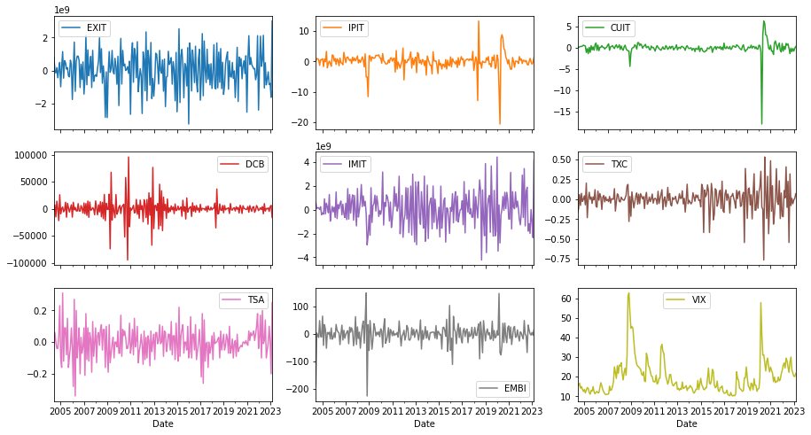

```python
dff.plot(subplots=True, layout=(3, 3), figsize=(15,8));
```

### Análise pré-modelagem

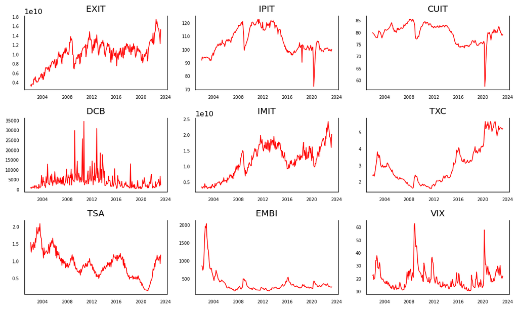

```python
# Plot
fig, axes = plt.subplots(nrows=3, ncols=3, dpi=120, figsize=(10,6))
for i, ax in enumerate(axes.flatten()):
    data = df[df.columns[i]]
    ax.plot(data, color='red', linewidth=1)
    # Decorations
    ax.set_title(df.columns[i])
    ax.xaxis.set_ticks_position('none')
    ax.yaxis.set_ticks_position('none')
    ax.spines["top"].set_alpha(0)
    ax.tick_params(labelsize=6)

plt.tight_layout();
```

Cada uma das séries possuem características próprias, mas nota-se correlações econômicas esperadas.  
Observa-se que na crise do subprime em 2008 ouve um aumento nos índices de risco nacional e internacional, junto com uma queda dos índices de produção da indústria de transformação, o que impactou na quantidade exportada e importada de bens de capital, além de uma subida na selic acumulada. Nota-se que o governo adotou uma politica de subsídios dada a incerteza pós crise, aumentando o crédito direcionado a partir de uma medida anti-cíclica. É possível notar que o período de maior desembolso de crédito do BNDES refletiu em maior produtividade na indústria para o período analisado (2002-2023).

### Modelagem VAR-VECM

Pela diferença de integração das séries, já podemos descartar a utilização do modelo VECM. No entanto, será analisadada a cointegração de longo prazo a partir do teste de Soren Johansen.

#### Cointegração

A ordem de integração(d) é o número de diferenças necessárias para tornar estacionária uma série temporal não estacionária.

Quando há duas ou mais séries temporais e existe uma combinação linear entre elas. Se a ordem do modelo tem uma ordem de integração (d) menor que a das séries individuais, diz-se que a coleção de séries é cointegrada.

Quando duas ou mais séries temporais são cointegradas, significa que elas possuem uma relação estatisticamente significativa de longo prazo.

Soren Johanssen em seu artigo (1991) desenvolveu um procedimento para implementar o teste de cointegração.

```python
from statsmodels.tsa.vector_ar.vecm import coint_johansen

def cointegration_test(df, alpha=0.05):
    """Perform Johanson's Cointegration Test and Report Summary"""
    out = coint_johansen(df,-1,5)
    d = {'0.90':0, '0.95':1, '0.99':2}
    traces = out.lr1
    cvts = out.cvt[:, d[str(1-alpha)]]
    def adjust(val, length= 6): return str(val).ljust(length)

    # Summary
    print('Name   ::  Test Stat > C(95%)    =>   Signif  \n', '--'*20)
    for col, trace, cvt in zip(df.columns, traces, cvts):
        print(adjust(col), ':: ', adjust(round(trace,2), 9), ">", adjust(cvt, 8), ' =>  ' , trace > cvt)

cointegration_test(df)
cointegration_test(dff)
```

```
Name   ::  Test Stat > C(95%)    =>   Signif
 ----------------------------------------
EXIT   ::  231.83    > 179.5199  =>   True
IPIT   ::  170.76    > 143.6691  =>   True
CUIT   ::  124.62    > 111.7797  =>   True
DCB    ::  86.31     > 83.9383   =>   True
IMIT   ::  59.87     > 60.0627   =>   False
TXC    ::  38.81     > 40.1749   =>   False
TSA    ::  20.12     > 24.2761   =>   False
EMBI   ::  6.8       > 12.3212   =>   False
VIX    ::  0.48      > 4.1296    =>   False
Name   ::  Test Stat > C(95%)    =>   Signif
 ----------------------------------------
EXIT   ::  656.06    > 179.5199  =>   True
IPIT   ::  467.78    > 143.6691  =>   True
CUIT   ::  349.71    > 111.7797  =>   True
DCB    ::  259.81    > 83.9383   =>   True
IMIT   ::  176.83    > 60.0627   =>   True
TXC    ::  110.47    > 40.1749   =>   True
TSA    ::  56.95     > 24.2761   =>   True
EMBI   ::  14.0      > 12.3212   =>   True
VIX    ::  0.49      > 4.1296    =>   False
```

Podemos analisar que apenas a variável de risco externo VIX não tem correlação de longo prazo com as demais após aplicação das diferenciações para estacionariedade. No entanto, Para as séries originais, ou seja, grau de difeferenciação I(0), observa-se que apenas as variáveis de exportação, índice de produção, capacidade de utilização e desembolso de crédito são correlacionadas. Assim, seguiremos com o modelo VAR.

### Modelo Vetor Autorregressivo (VAR)

Para selecionar a ordem correta do modelo VAR, ajusta-se iterativamente as ordens crescentes do modelo e seleciona a ordem (p) que fornece um modelo com menor valor entre os testes 'AIC', 'BIC', 'FPE' e 'HQIC'.

```python
model = VAR(dff)
for i in [1,2,3,4,5,6,7,8,9]:
    result = model.fit(i)
    print('Lag Order =', i)
    print('AIC : ', result.aic)
    print('BIC : ', result.bic)
    print('FPE : ', result.fpe)
    print('HQIC: ', result.hqic, '\n')
```

```
Lag Order = 1
AIC :  104.20635069085431
BIC :  105.57279085173607
FPE :  1.8049788608407912e+45
HQIC:  104.75785154966339

Lag Order = 2
AIC :  103.2043183831264
BIC :  105.80874461021217
FPE :  6.647572529851675e+44
HQIC:  104.25559173662063

Lag Order = 3
AIC :  102.81233117583132
BIC :  106.66258806555307
FPE :  4.529347199803307e+44
HQIC:  104.36665401814001

Lag Order = 4
AIC :  102.49329327078291
BIC :  107.59730934359133
FPE :  3.3461127824149084e+44
HQIC:  104.55397719724543

Lag Order = 5
AIC :  102.23246752411899
BIC :  108.59825647628347
FPE :  2.649262389927877e+44
HQIC:  104.80285922782282

Lag Order = 6
AIC :  102.21572568149928
BIC :  109.8513876607921
FPE :  2.716684501833468e+44
HQIC:  105.29920745871225

Lag Order = 7
AIC :  102.18872941532595
BIC :  111.1024523211447
FPE :  2.809221440453566e+44
HQIC:  105.78871968001032

Lag Order = 8
AIC :  102.16556564133832
BIC :  112.36562644983572
FPE :  2.985013700388001e+44
HQIC:  106.28551944893904

Lag Order = 9
AIC :  102.24418420537754
BIC :  113.73895032018333
FPE :  3.6150871031250726e+44
HQIC:  106.88759378608161
```

Será utilizado modelo com lag 2.

Um método alternativo para escolher a ordem(p) dos modelos VAR é usar o método: model.select_order(maxlags) do statsmodel.

```python
x = model.select_order(maxlags=12)
x.summary()
```

VAR Order Selection (* highlights the minimums)

|  | AIC | BIC | FPE | HQIC |
| --- | --- | --- | --- | --- |
| 0 | 107.7 | 107.9 | 6.134e+46 | 107.8 |
| 1 | 104.3 | 105.7* | 1.984e+45 | 104.9 |
| 2 | 103.3 | 106.0 | 7.037e+44 | 104.3* |
| 3 | 102.8 | 106.8 | 4.509e+44 | 104.4 |
| 4 | 102.4 | 107.7 | 3.194e+44 | 104.6 |
| 5 | 102.2 | 108.7 | 2.499e+44 | 104.8 |
| 6 | 102.1 | 109.9 | 2.390e+44* | 105.2 |
| 7 | 102.2 | 111.2 | 2.743e+44 | 105.8 |
| 8 | 102.2 | 112.5 | 3.012e+44 | 106.3 |
| 9 | 102.2 | 113.8 | 3.641e+44 | 106.9 |
| 10 | 102.1 | 115.0 | 3.742e+44 | 107.3 |
| 11 | 102.0 | 116.2 | 4.032e+44 | 107.7 |
| 12 | 101.7* | 117.2 | 3.957e+44 | 108.0 |

#### Configurando o Modelo VAR

```python
model_fit = model.fit(2)
model_fit.summary()
```

```
  Summary of Regression Results
==================================
Model:                         VAR
Method:                        OLS
Date:           Fri, 21, Jul, 2023
Time:                     20:34:51
--------------------------------------------------------------------
No. of Equations:         9.00000    BIC:                    105.809
Nobs:                     224.000    HQIC:                   104.256
Log likelihood:          -14248.5    FPE:                6.64757e+44
AIC:                      103.204    Det(Omega_mle):     3.19476e+44
--------------------------------------------------------------------
Results for equation EXIT
===============================================================================
                coefficient         std. error           t-stat            prob
-------------------------------------------------------------------------------
const      301958544.893174   175439001.810870            1.721           0.085
L1.EXIT           -0.271862           0.083343           -3.262           0.001
L1.IPIT    -23521013.676873    34383760.803876           -0.684           0.494
L1.CUIT     26702859.756316    67146195.012260            0.398           0.691
L1.DCB          1313.028474        5252.715540            0.250           0.803
L1.IMIT            0.177273           0.064458            2.750           0.006
L1.TXC     215619259.268894   584217747.206851            0.369           0.712
L1.TSA   -5503346593.009548   975744900.446098           -5.640           0.000
L1.EMBI     -2642659.432191     2993698.564800           -0.883           0.377
L1.VIX     -22567676.310195    17515182.786735           -1.288           0.198
L2.EXIT           -0.179113           0.083613           -2.142           0.032
L2.IPIT     25176197.922492    35553554.458521            0.708           0.479
L2.CUIT    -36610910.948431    58454137.073054           -0.626           0.531
L2.DCB         -4078.840134        5231.878470           -0.780           0.436
L2.IMIT            0.139209           0.066352            2.098           0.036
L2.TXC     211215003.231370   566052104.424206            0.373           0.709
L2.TSA   -1880401345.143316  1035599705.546121           -1.816           0.069
L2.EMBI       501503.953701     2502765.686360            0.200           0.841
L2.VIX       8154210.640271    18388741.647589            0.443           0.657
===============================================================================

Results for equation IPIT
==========================================================================
             coefficient       std. error           t-stat            prob
```

[output cut: 193 more lines]

```
L2.EMBI        -0.011590         0.011635           -0.996           0.319
L2.VIX         -0.136926         0.085485           -1.602           0.109
==========================================================================

Correlation matrix of residuals
            EXIT      IPIT      CUIT       DCB      IMIT       TXC       TSA      EMBI       VIX
EXIT    1.000000  0.122294  0.016919 -0.024076  0.515020 -0.008632  0.490950  0.055449  0.068458
IPIT    0.122294  1.000000  0.590444  0.073592  0.208979 -0.139993 -0.027459 -0.144014 -0.044670
CUIT    0.016919  0.590444  1.000000 -0.065170  0.138099 -0.089481 -0.046528 -0.097474  0.086839
DCB    -0.024076  0.073592 -0.065170  1.000000  0.014644 -0.008315  0.037900  0.087651  0.056613
IMIT    0.515020  0.208979  0.138099  0.014644  1.000000  0.009303  0.444912  0.014413  0.103058
TXC    -0.008632 -0.139993 -0.089481 -0.008315  0.009303  1.000000  0.068299  0.609987  0.283865
TSA     0.490950 -0.027459 -0.046528  0.037900  0.444912  0.068299  1.000000  0.080492  0.106322
EMBI    0.055449 -0.144014 -0.097474  0.087651  0.014413  0.609987  0.080492  1.000000  0.562276
VIX     0.068458 -0.044670  0.086839  0.056613  0.103058  0.283865  0.106322  0.562276  1.000000
```

#### Estabilidade do modelo VAR

- Para checar a estabilidade do modelo, no statsmodel do python há a função "is_stable" que retorna True ou False.

```python
# Check stability
is_stable = model_fit.is_stable()
print("Model stability:", is_stable)
```

```
Model stability: True
```

- Assim, nota-se que o modelo é estável e todas as raízes são menores do que 1.

Para adquirir o valor de cada raíz do modelo, foi aplicado na linguagem R a função root, com os seguintes valores:

0.99629463, 0.96292764, 0.96292764, 0.87005282, 0.87005282, 0.82296431, 0.70148616, 0.56769303, 0.02775257

O que assegura que o modelo é realmente estável.

Já para assegurar o correlograma dentro do intervalo de confiança, tem-se a figura a seguir:

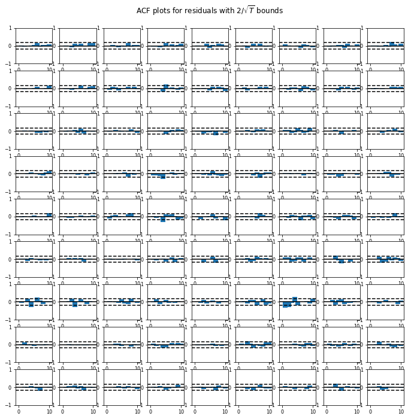

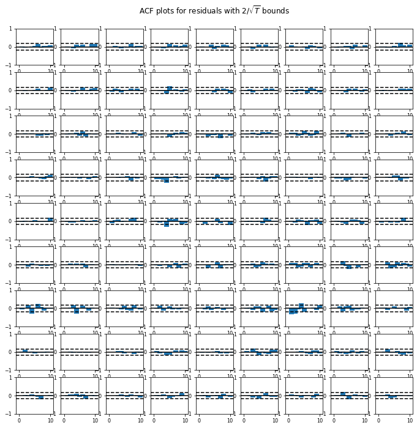

```python
plt.figure(figsize = (20,40))

model_fit.plot_acorr()
```

- Nota-se que todos os resíduos estão dentro do do intervalo de confiança, com pequenas exceções que serão desconsideradas dada a relevância.

Aplicando o teste de Jarque-Bera

```python
norm_test = model_fit.test_normality()
norm_test.summary()
```

normality (skew and kurtosis) test. H_0: data generated by normally-distributed process. Conclusion: reject H_0 at 5% significance level.

| Test statistic | Critical value | p-value | df |
| --- | --- | --- | --- |
| 2972. | 28.87 | 0.000 | 18 |

Para o teste de Jarque-Bera rejeitou-se a hipótese nula para um intervalo de confiança de 5\%, ou seja, o modelo não apresenta normalidade a partir da curtose.

Aplicando o teste de Portmanteau

```python
norm_port = model_fit.test_whiteness(nlags=12, adjusted=True)
norm_port.summary()
```

Adjusted Portmanteau-test for residual autocorrelation. H_0: residual autocorrelation up to lag 12 is zero. Conclusion: reject H_0 at 5% significance level.

| Test statistic | Critical value | p-value | df |
| --- | --- | --- | --- |
| 1184. | 877.3 | 0.000 | 810 |

O teste de Portmanteau para 12 defasagens rejeitou-se a hipótese nula, logo há autocorrelação dos resíduos e são diferentes de zero.

#### Causalide de Granger

Aplicando o teste de Granger-Causa.

```python
test_caus = model_fit.test_inst_causality(causing=['DCB'],  signif=0.05)
test_caus.summary()
```

Instantaneous causality Wald-test. H_0: DCB does not instantaneously cause [EXIT, IPIT, CUIT, IMIT, TXC, TSA, EMBI, VIX]. Conclusion: fail to reject H_0 at 5% significance level.

| Test statistic | Critical value | p-value | df |
| --- | --- | --- | --- |
| 9.790 | 15.51 | 0.280 | 8 |

Outra forma de analisar a causalidade de granger é aplicando o teste de forma univariada.

A causalidade de Granger testa a hipótese nula de que os coeficientes de valores passados na equação de regressão são zero.

Em termos gerais, os valores passados de uma série temporal X não causam a outra série Y. Portanto, se o p-valor obtido no teste for menor que o nível de significância de 0,05, podemos rejeitar a hipótese nula.

```python
from statsmodels.tsa.stattools import grangercausalitytests
maxlag=12
test = 'ssr_chi2test'
def grangers_causation_matrix(data, variables, test='ssr_chi2test', verbose=False):
    """Check Granger Causality of all possible combinations of the Time series.
    The rows are the response variable, columns are predictors. The values in the table
    are the P-Values. P-Values lesser than the significance level (0.05), implies
    the Null Hypothesis that the coefficients of the corresponding past values is
    zero, that is, the X does not cause Y can be rejected.

    data      : pandas dataframe containing the time series variables
    variables : list containing names of the time series variables.
    """
    df = pd.DataFrame(np.zeros((len(variables), len(variables))), columns=variables, index=variables)
    for c in df.columns:
        for r in df.index:
            test_result = grangercausalitytests(data[[r, c]], maxlag=maxlag, verbose=False)
            p_values = [round(test_result[i+1][0][test][1],4) for i in range(maxlag)]
            if verbose: print(f'Y = {r}, X = {c}, P Values = {p_values}')
            min_p_value = np.min(p_values)
            df.loc[r, c] = min_p_value
    df.columns = [var + '_x' for var in variables]
    df.index = [var + '_y' for var in variables]
    return df

grangers_causation_matrix(dff, variables = dff.columns)
```

|  | EXIT_x | IPIT_x | CUIT_x | DCB_x | IMIT_x | TXC_x | TSA_x | EMBI_x | VIX_x |
| --- | --- | --- | --- | --- | --- | --- | --- | --- | --- |
| EXIT_y | 1.0000 | 0.0003 | 0.0001 | 0.0181 | 0.0019 | 0.2486 | 0.0000 | 0.0860 | 0.0216 |
| IPIT_y | 0.3931 | 1.0000 | 0.3920 | 0.3423 | 0.3232 | 0.0131 | 0.1643 | 0.0215 | 0.0000 |
| CUIT_y | 0.0893 | 0.0000 | 1.0000 | 0.9457 | 0.0006 | 0.0013 | 0.3556 | 0.0001 | 0.0000 |
| DCB_y | 0.0062 | 0.0962 | 0.5715 | 1.0000 | 0.0038 | 0.6412 | 0.1899 | 0.0041 | 0.0235 |
| IMIT_y | 0.0000 | 0.0000 | 0.0000 | 0.2440 | 1.0000 | 0.0002 | 0.0000 | 0.0070 | 0.0000 |
| TXC_y | 0.0187 | 0.0000 | 0.0000 | 0.5794 | 0.0000 | 1.0000 | 0.5159 | 0.0763 | 0.0000 |
| TSA_y | 0.0000 | 0.4139 | 0.3088 | 0.0344 | 0.0009 | 0.1546 | 1.0000 | 0.1087 | 0.1355 |
| EMBI_y | 0.0170 | 0.0040 | 0.0014 | 0.4189 | 0.0038 | 0.1193 | 0.1065 | 1.0000 | 0.0000 |
| VIX_y | 0.0591 | 0.1424 | 0.2581 | 0.7155 | 0.0032 | 0.2530 | 0.0487 | 0.3886 | 1.0000 |

Tem-se os valores de p-valor nas linhas (y) em que cada variável (x) causa ou não a série analisada. Assim, serão utilizadas as variáveis com p-valor<0,05.

Foi aplicado um teste de causalidade univariado em cada variável. Notou-se que apenas a taxa de câmbio e o índice de risco embi não granger-causam as exportações. Este resultado surpreende dada a influência direta da taxa de câmbio na incerteza de exportação. Já o índice de produção industrial é o inverso da variável de exportação, pois granger-causa significativamente a taxa de câmbio, e as duas variáveis de risco. Sendo assim, as principais variáveis de incerteza apresentam um reflexo maior na produção do que na exportação.

- Função impulso resposta

```python
irf = model_fit.irf(10)
```

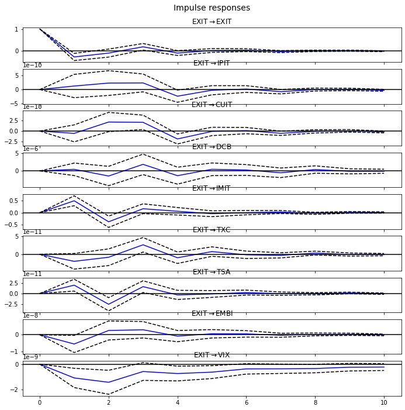

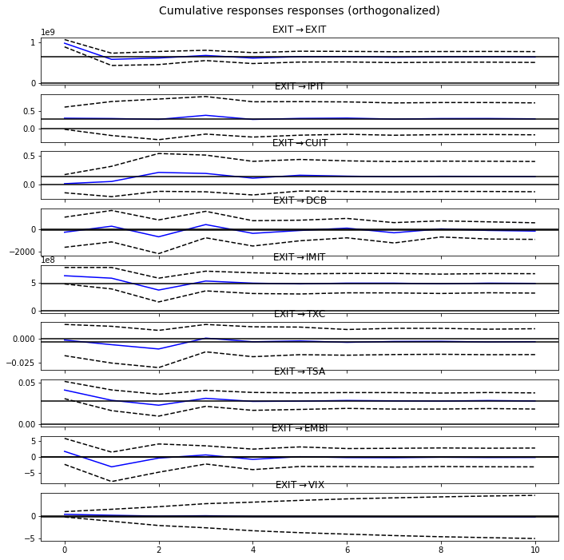

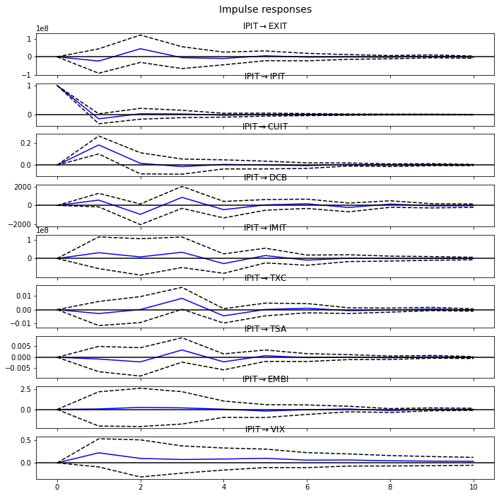

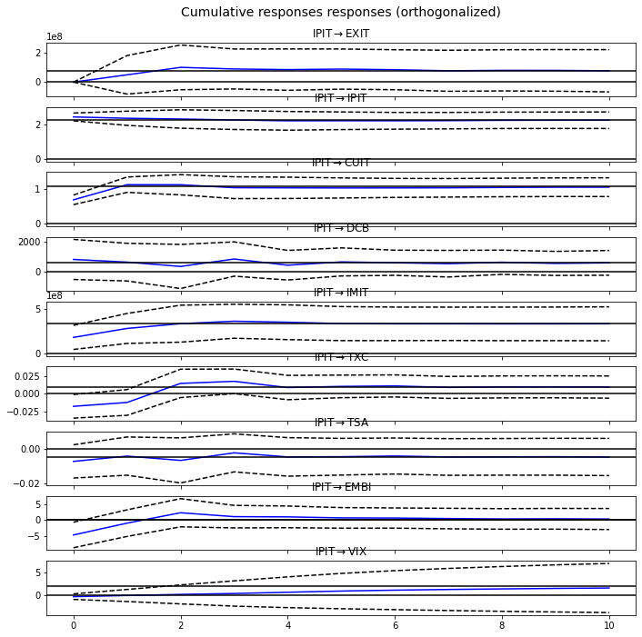

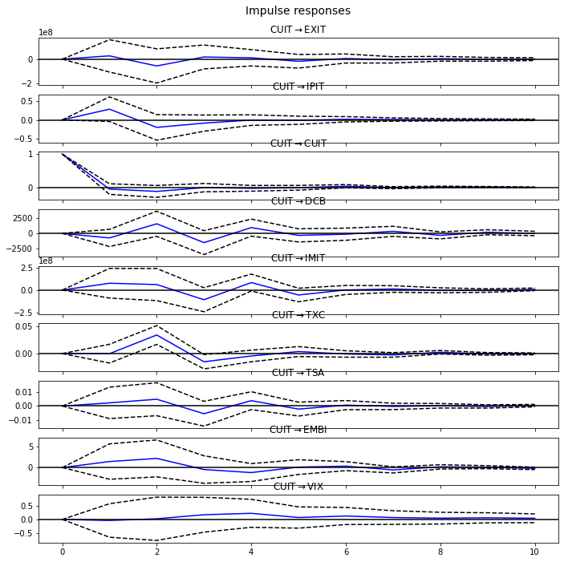

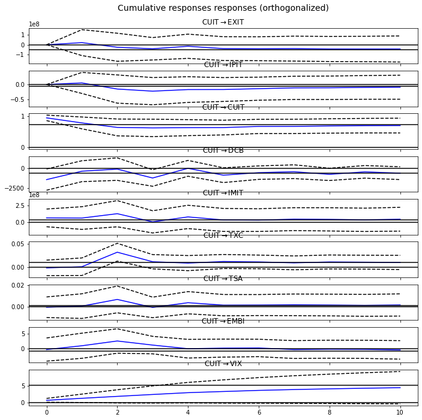

```python
for col in ['EXIT','IPIT','CUIT']:
    #impulso resposta para exportacao
    irf.plot(impulse=col)
    #acumulado no tempo do impulso resposta para exportacao
    irf.plot_cum_effects(orth=True, impulse=col)
```

- Decomposição da variância

```python
fevd = model_fit.fevd(6)
fevd.summary()
```

```
FEVD for EXIT
         EXIT      IPIT      CUIT       DCB      IMIT       TXC       TSA      EMBI       VIX
0    1.000000  0.000000  0.000000  0.000000  0.000000  0.000000  0.000000  0.000000  0.000000
1    0.859423  0.001867  0.000376  0.000456  0.003147  0.004104  0.115512  0.009881  0.005235
2    0.834151  0.003707  0.002076  0.001917  0.010359  0.006324  0.121054  0.014285  0.006127
3    0.806968  0.003658  0.002183  0.006493  0.032204  0.006813  0.116899  0.016901  0.007882
4    0.800092  0.003626  0.002644  0.011018  0.035096  0.006730  0.116308  0.016695  0.007790
5    0.798016  0.003621  0.003063  0.011601  0.034966  0.007414  0.116594  0.016663  0.008063

FEVD for IPIT
         EXIT      IPIT      CUIT       DCB      IMIT       TXC       TSA      EMBI       VIX
0    0.014956  0.985044  0.000000  0.000000  0.000000  0.000000  0.000000  0.000000  0.000000
1    0.011163  0.735297  0.000366  0.003417  0.000432  0.022933  0.008487  0.002629  0.215275
2    0.010938  0.716107  0.005640  0.003801  0.005363  0.022446  0.017197  0.008176  0.210332
3    0.012344  0.702728  0.006157  0.005398  0.010712  0.022661  0.016961  0.011510  0.211529
4    0.013843  0.694609  0.006431  0.006429  0.013597  0.022768  0.016927  0.012251  0.213145
5    0.013902  0.692531  0.006412  0.007261  0.013926  0.022715  0.017246  0.012235  0.213772

FEVD for CUIT
         EXIT      IPIT      CUIT       DCB      IMIT       TXC       TSA      EMBI       VIX
0    0.000286  0.351441  0.648273  0.000000  0.000000  0.000000  0.000000  0.000000  0.000000
1    0.000847  0.321955  0.435601  0.001141  0.000140  0.033701  0.000225  0.014018  0.192372
2    0.011231  0.300521  0.415721  0.001884  0.001336  0.033605  0.023578  0.013091  0.199033
3    0.010840  0.289805  0.396658  0.001925  0.037595  0.033413  0.023987  0.012512  0.193265
4    0.013185  0.282399  0.386541  0.001880  0.043965  0.034672  0.023931  0.015495  0.197932
5    0.014081  0.280308  0.383673  0.002006  0.044825  0.034785  0.025051  0.016100  0.199171

FEVD for DCB
         EXIT      IPIT      CUIT       DCB      IMIT       TXC       TSA      EMBI       VIX
0    0.000580  0.005947  0.018828  0.974646  0.000000  0.000000  0.000000  0.000000  0.000000
1    0.001411  0.002648  0.012444  0.979795  0.000984  0.000231  0.000014  0.000212  0.002262
2    0.003977  0.002378  0.010129  0.968290  0.005753  0.001178  0.000193  0.001913  0.006190
3    0.007515  0.003064  0.013629  0.945963  0.012023  0.001530  0.000630  0.008354  0.007290
4    0.009133  0.003488  0.017637  0.933064  0.013819  0.001499  0.000972  0.013268  0.007120
5    0.008931  0.003480  0.019011  0.931765  0.013264  0.001962  0.001125  0.013392  0.007070

FEVD for IMIT
         EXIT      IPIT      CUIT       DCB      IMIT       TXC       TSA      EMBI       VIX
0    0.265246  0.021638  0.002745  0.000538  0.709834  0.000000  0.000000  0.000000  0.000000
1    0.188599  0.020149  0.001945  0.000543  0.689124  0.007982  0.056520  0.014138  0.021001
```

[output cut: 25 more lines]

```
0    0.003075  0.023084  0.000107  0.010113  0.000058  0.354134  0.000007  0.609422  0.000000
1    0.020513  0.028268  0.001434  0.007848  0.002437  0.316597  0.001287  0.621239  0.000378
2    0.025125  0.035027  0.003385  0.008054  0.004431  0.311715  0.007668  0.593021  0.011575
3    0.025019  0.034990  0.004718  0.007959  0.017654  0.304066  0.008123  0.574762  0.022710
4    0.026161  0.034681  0.005799  0.008058  0.017700  0.301597  0.010234  0.573055  0.022715
5    0.026583  0.034660  0.005813  0.008448  0.017663  0.302271  0.010269  0.571612  0.022681

FEVD for VIX
         EXIT      IPIT      CUIT       DCB      IMIT       TXC       TSA      EMBI       VIX
0    0.004687  0.002856  0.021247  0.006964  0.006154  0.077163  0.001369  0.233813  0.645747
1    0.003470  0.002940  0.020157  0.007396  0.015662  0.083968  0.017638  0.209760  0.639008
2    0.003196  0.003197  0.021456  0.007265  0.055443  0.082915  0.019182  0.192980  0.614366
3    0.002884  0.003373  0.024077  0.007511  0.056150  0.082878  0.019990  0.191113  0.612024
4    0.002989  0.004135  0.026550  0.007570  0.057557  0.085940  0.019879  0.189175  0.606204
5    0.002839  0.004813  0.026941  0.007449  0.061108  0.085133  0.020335  0.188738  0.602643
```

[figure not shown]

[figure not shown]

```python
model_fit.fevd(20).plot()
```

```python
model_fit.resid.mean()
```

```
EXIT    4.108463e-07
IPIT   -2.424648e-15
CUIT    1.105762e-15
DCB     7.803789e-12
IMIT    1.500760e-06
TXC     1.286174e-16
TSA     5.154607e-17
EMBI    3.985701e-14
VIX     2.826311e-14
dtype: float64
```